# Assignment 3 Copy

## Wrangling Risk Factors

```r
#-----Risk factors-----

#311streetlights
streetLightsOut <-
  read.socrata("https://data.cityofchicago.org/Service-Requests/311-Service-Requests-Street-Lights-All-Out/zuxi-7xem") %>%
    mutate(year = substr(creation_date,1,4)) %>% filter(year == "2018") %>%
    dplyr::select(Y = latitude, X = longitude) %>%
    na.omit() %>%
    st_as_sf(coords = c("X", "Y"), crs = 4326, agr = "constant") %>%
    st_transform(st_crs(fishnet)) %>%
    mutate(Legend = "Street_Lights_Out")

#liquor stores
liquorRetail <-
  read.socrata("https://data.cityofchicago.org/resource/nrmj-3kcf.json") %>%
    filter(business_activity == "Retail Sales of Packaged Liquor") %>%
    dplyr::select(Y = latitude, X = longitude) %>%
    na.omit() %>%
    st_as_sf(coords = c("X", "Y"), crs = 4326, agr = "constant") %>%
    st_transform(st_crs(fishnet)) %>%
    mutate(Legend = "Liquor_Retail")

#311 potholes
potholes <-
  read.socrata("https://data.cityofchicago.org/resource/_311-potholes.json") %>%
    mutate(year = substr(creation_date,1,4)) %>% filter(year == "2018") %>%
    dplyr::select(Y = latitude, X = longitude) %>%
    na.omit() %>%
    st_as_sf(coords = c("X", "Y"), crs = 4326, agr = "constant") %>%
    st_transform(st_crs(fishnet)) %>%
    mutate(Legend = "Potholes")

#red light crossings
redlight <-
  read.socrata("https://data.cityofchicago.org/resource/spqx-js37.json") %>%
  mutate(year = substr(violation_date,1,4)) %>% filter(year == "2018")%>%
    dplyr::select(Y = latitude, X = longitude) %>%
    na.omit() %>%
    st_as_sf(coords = c("X", "Y"), crs = 4326, agr = "constant") %>%
    st_transform(st_crs(fishnet)) %>%
    mutate(Legend = "Red_Light_Crossings")


#speed camera violations
speedcamera <-
  read.socrata("https://data.cityofchicago.org/resource/hhkd-xvj4.json") %>%
  mutate(year = substr(violation_date,1,4)) %>% filter(year == "2018")%>%
    dplyr::select(Y = latitude, X = longitude) %>%
    na.omit() %>%
    st_as_sf(coords = c("X", "Y"), crs = 4326, agr = "constant") %>%
    st_transform(st_crs(fishnet)) %>%
    mutate(Legend = "Speed_Camera_Violations")

#bus stops
busstops <-
  st_read("~/CPLNPennDesign/590-Musa/Musa508-Vero/CTA_BusStops/CTA_BusStops.shp") %>%
  st_transform('ESRI:102271') %>%
  #dplyr::select(Y = latitude, X = longitude) %>%
  na.omit() %>%
  st_as_sf(coords = c("X", "Y"), crs = 4326, agr = "constant") %>%
  st_transform(st_crs(fishnet)) %>%
  mutate(Legend = "Bus Stops")
neighborhoods <-
  st_read("https://raw.githubusercontent.com/blackmad/neighborhoods/master/chicago.geojson") %>%
  st_transform(st_crs(fishnet))
```

[figure not shown]

```r
#-----Count of Risk Factors by Fishnet-----

vars_net <-
  bind_rows(streetLightsOut, liquorRetail, potholes, redlight, speedcamera, busstops)%>%
  st_join(., fishnet, join=st_within) %>%
  st_drop_geometry() %>%
  group_by(uniqueID, Legend) %>%
  summarize(count = n()) %>%
  full_join(fishnet) %>%
  spread(Legend, count, fill=0) %>%
  st_sf() %>%
  dplyr::select(-`<NA>`) %>%
  na.omit() %>%
  ungroup()

vars_net.long <-
  gather(vars_net, Variable, value, -geometry, -uniqueID)

vars <- unique(vars_net.long$Variable)
mapList <- list()

for(i in vars){
  mapList[[i]] <-
    ggplot() +
    geom_sf(data = filter(vars_net.long, Variable == i), aes(fill=value), colour=NA) +
    scale_fill_viridis(name="") +
    labs(title=i) +
    mapTheme()}

do.call(grid.arrange,c(mapList, ncol=3, top="Risk Factors by Fishnet"))
```

The plots above show risk factors by count spatially distributed. The top three factors show a bit of clustering, while the bottom three show greater dispersion.

## NN Risk Factors

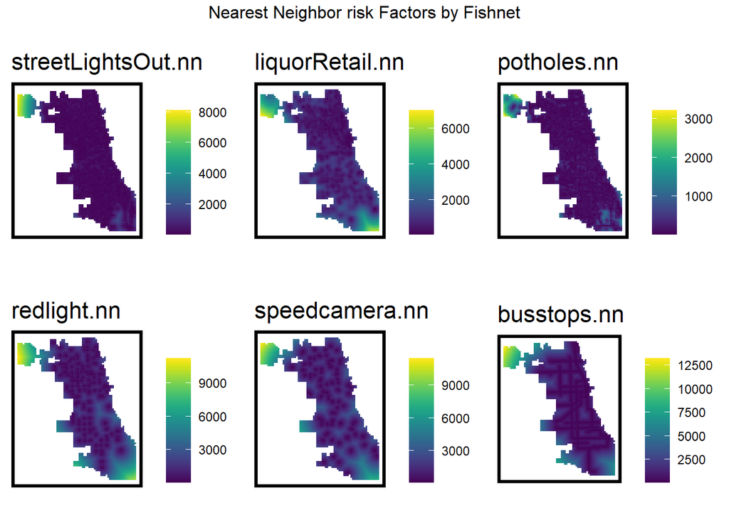

```r
#-----Feature Engineering - Nearest Neighbors-----
st_c <- st_coordinates
st_coid <- st_centroid

vars_net <-
  vars_net %>%
    mutate(
      streetLightsOut.nn =
        nn_function(st_c(st_coid(vars_net)), st_c(streetLightsOut),3),
      liquorRetail.nn =
        nn_function(st_c(st_coid(vars_net)), st_c(liquorRetail),3),
      potholes.nn =
        nn_function(st_c(st_coid(vars_net)), st_c(potholes),3),
      redlight.nn =
        nn_function(st_c(st_coid(vars_net)), st_c(redlight),3),
      speedcamera.nn =
        nn_function(st_c(st_coid(vars_net)), st_c(speedcamera),3),
      busstops.nn =
        nn_function(st_c(st_coid(vars_net)), st_c(busstops),3))

vars_net.long.nn <-
  dplyr::select(vars_net, ends_with(".nn")) %>%
    gather(Variable, value, -geometry)

vars <- unique(vars_net.long.nn$Variable)
mapList <- list()

for(i in vars){
  mapList[[i]] <-
    ggplot() +
      geom_sf(data = filter(vars_net.long.nn, Variable == i), aes(fill=value), colour=NA) +
      scale_fill_viridis(name="") +
      labs(title=i) +
      mapTheme()}

do.call(grid.arrange,c(mapList, ncol = 3, top = "Nearest Neighbor risk Factors by Fishnet"))
```

The plots above shows distance(nn) from the traffic crashes to risk factors. From the maps only, we could say that the degree of clustering is way less, but the scale at which we are observing these factors says little about the crashes. An interesting observation is in the speed camera violations and the redlight maps, which we could infer show a spatial pattern of “events” distributed across the entire geography. Contrarily, the potholes map shows that areas with less potholes (look at the count map) theoretically have less crashes, but because is clustered in a very specific zone, distance from potholes may tell us little about future crashes.

## Exploring the Spatial Process: Local Moran’s I

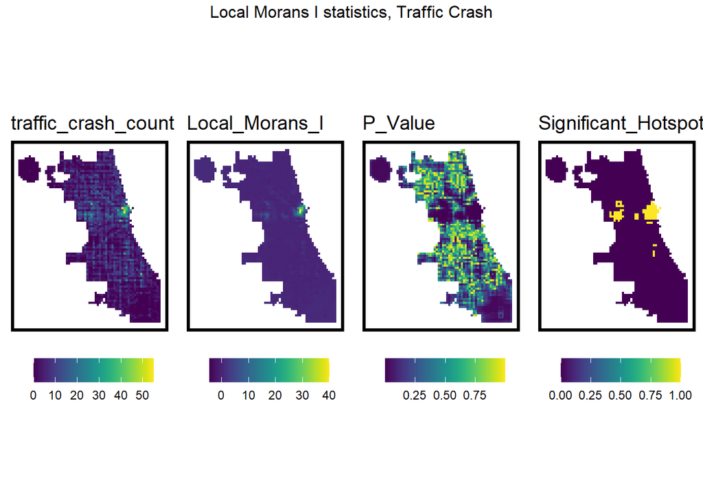

```r
## important to drop the geometry from joining features
final_net <-
  left_join(crash_net, st_drop_geometry(vars_net), by="uniqueID")

final_net <-
  st_centroid(final_net) %>%
    st_join(dplyr::select(neighborhoods, name), by = "uniqueID") %>%
    #st_join(dplyr::select(policeDistricts, District), by = "uniqueID") %>%
      st_drop_geometry() %>%
      left_join(dplyr::select(final_net, geometry, uniqueID)) %>%
      st_sf() %>%
  na.omit()

## generates warnings from PROJ issues
## {spdep} to make polygon to neighborhoods...
final_net.nb <- poly2nb(as_Spatial(final_net), queen=TRUE)
## ... and neighborhoods to list of weigths
final_net.weights <- nb2listw(final_net.nb, style="W", zero.policy=TRUE)

# print(final_net.weights, zero.policy=TRUE)
## see ?localmoran
local_morans <- localmoran(final_net$traffic_crash_count, final_net.weights, zero.policy=TRUE) %>%
  as.data.frame()

# join local Moran's I results to fishnet
final_net.localMorans <-
  cbind(local_morans, as.data.frame(final_net)) %>%
  st_sf() %>%
  dplyr::select(traffic_crash_count = traffic_crash_count,
                Local_Morans_I = Ii,
                P_Value = `Pr(z != E(Ii))`) %>%
  mutate(Significant_Hotspots = ifelse(P_Value <= 0.001, 1, 0)) %>%
  gather(Variable, Value, -geometry)

vars <- unique(final_net.localMorans$Variable)
varList <- list()

for(i in vars){
  varList[[i]] <-
    ggplot() +
      geom_sf(data = filter(final_net.localMorans, Variable == i),
              aes(fill = Value), colour=NA) +
      scale_fill_viridis(name="") +
      labs(title=i) +
      mapTheme(title_size = 14) + theme(legend.position="bottom")}

do.call(grid.arrange,c(varList, ncol = 4, top = "Local Morans I statistics, Traffic Crash"))
```

The multiple plots above show the areas with greater statistical significance and the concentration of crashes. Crashes are concentrated in the downtown area.

## Correlation

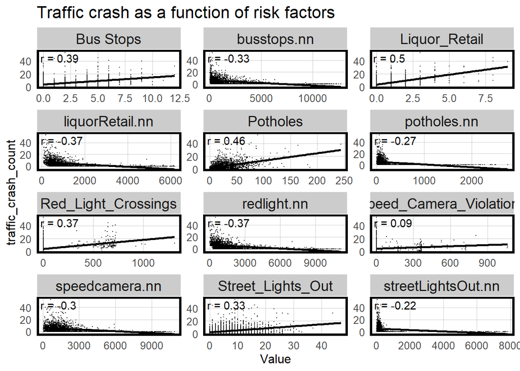

```r
correlation.long <-
  st_drop_geometry(final_net) %>%
    dplyr::select(-uniqueID, -cvID, -name) %>%
    gather(Variable, Value, -traffic_crash_count)

correlation.cor <-
  correlation.long %>%
    group_by(Variable) %>%
    summarize(correlation = cor(Value, traffic_crash_count, use = "complete.obs"))

ggplot(correlation.long, aes(Value, traffic_crash_count)) +
  geom_point(size = 0.1) +
  geom_text(data = correlation.cor, aes(label = paste("r =", round(correlation, 2))),
            x=-Inf, y=Inf, vjust = 1.5, hjust = -.1) +
  geom_smooth(method = "lm", se = FALSE, colour = "black") +
  facet_wrap(~Variable, ncol = 3, scales = "free") +
  labs(title = "Traffic crash as a function of risk factors") +
  plotTheme()
```

These corr plots show that while count has a positive correlation to crashes, distance mostly has a negative correlation. Greater distance to risk factors implies less crashes. Greater count of risk factors implies greater number of crash instances. Higher count of bus stops and liquor retail show greater crash instances as well. If a second model was developed, count of other street amenities and retail could be risk factors to consider as they imply potential congestion points on the ground.

## Distance to Hot Spots

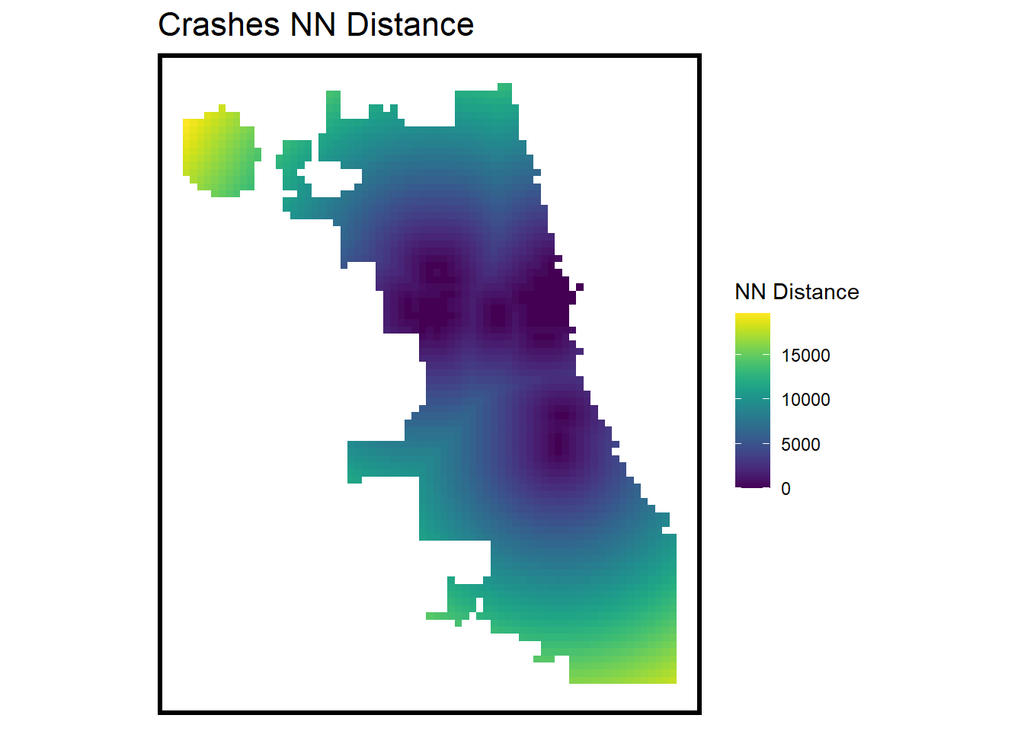

```r
final_net <- final_net %>%
  mutate(crash.isSig =
           ifelse(local_morans[,5] <= 0.001, 1, 0)) %>%
  mutate(crash.isSig.dist =
           nn_function(st_c(st_coid(final_net)),
                       st_c(st_coid(filter(final_net,
                                           crash.isSig == 1))),
                       k = 1))

ggplot() +
      geom_sf(data = final_net, aes(fill=crash.isSig.dist), colour=NA) +
      scale_fill_viridis(name="NN Distance") +
      labs(title="Crashes NN Distance") +
      mapTheme()
```

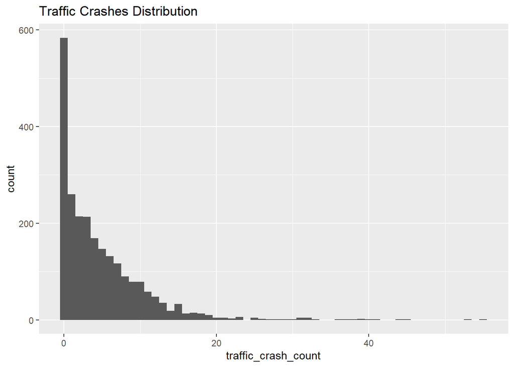

```r
#Histogram of Dependent Variable
ggplot(final_net, aes(traffic_crash_count)) +
  geom_histogram(binwidth = 1) +
  labs(title = "Traffic Crashes Distribution")
```

## Errors by Neighborhood

Errors calculated by neighborhood to test model performance on different group contexts

```r
#Calculate errors by NEIGHBORHOOD
error_by_reg_and_fold <-
  reg.summary %>%
  group_by(Regression, cvID) %>%
  summarize(Mean_Error = mean(Prediction - traffic_crash_count, na.rm = T),
            MAE = mean(abs(Mean_Error), na.rm = T),
            SD_MAE = mean(abs(Mean_Error), na.rm = T)) %>%
  ungroup()

error_by_reg_and_fold %>% arrange(desc(MAE))

error_by_reg_and_fold %>% arrange(MAE)
```

[output not shown]

## Plots: Accuracy and Generalizability

Cross validation leaving one neighborhood out per iteration.

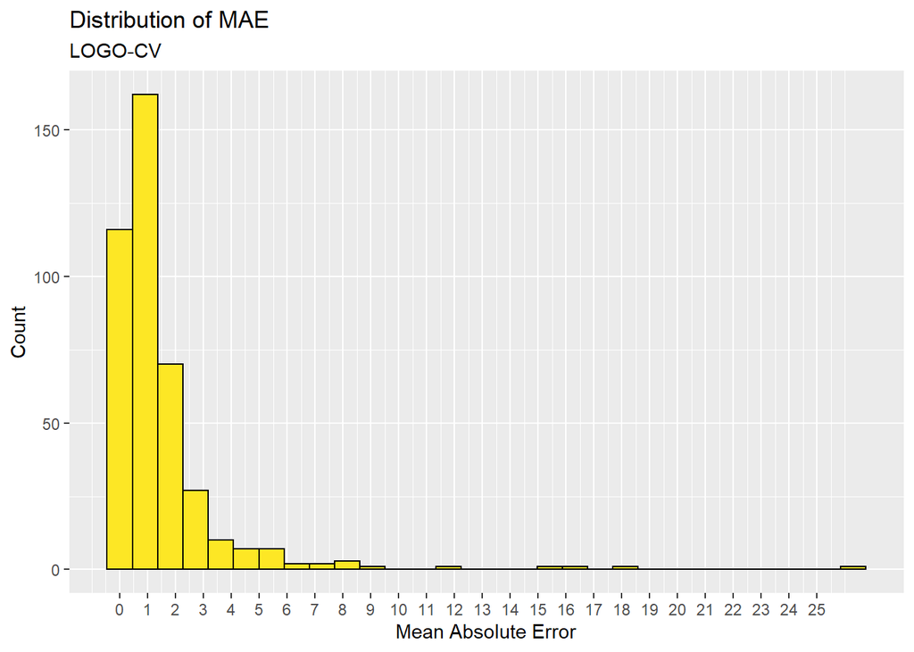

```r
#plot histogram of OOF (out of fold) errors
error_by_reg_and_fold %>%
  ggplot(aes(MAE)) +
    geom_histogram(bins = 30, colour="black", fill = "#FDE725FF") +
  scale_x_continuous(breaks = seq(0, 25, by = 1)) +
    labs(title="Distribution of MAE", subtitle = "LOGO-CV",
         x="Mean Absolute Error", y="Count")
```

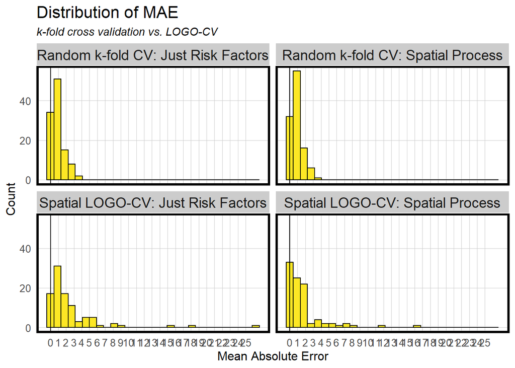

```r
error_by_reg_and_fold %>%
  ggplot(aes(MAE)) +
    geom_histogram(bins = 30, colour="black", fill = "#FDE725FF") +
    facet_wrap(~Regression) +
    geom_vline(xintercept = 0) + scale_x_continuous(breaks = seq(0, 25, by = 1)) +
    labs(title="Distribution of MAE", subtitle = "k-fold cross validation vs. LOGO-CV",
         x="Mean Absolute Error", y="Count") +
    plotTheme()
```

The spatial process features show an account of crashes across Chicago at a greater resolution than the features without it. This is an important verification step to improve future predictions beyond Chicago (other cities).

## Regressions Table

```r
st_drop_geometry(error_by_reg_and_fold) %>%
  group_by(Regression) %>%
  summarize(Mean_MAE = round(mean(MAE), 2),SD_MAE = round(sd(MAE), 2)) %>%
kable() %>%
    kable_styling("striped", full_width = F) %>%
    row_spec(2, color = "black", background = "#FDE725FF") %>%
    row_spec(4, color = "black", background = "#FDE725FF")
```

| Regression | Mean_MAE | SD_MAE |
| --- | --- | --- |
| Random k-fold CV: Just Risk Factors | 0.96 | 0.75 |
| Random k-fold CV: Spatial Process | 0.91 | 0.73 |
| Spatial LOGO-CV: Just Risk Factors | 2.49 | 3.80 |
| Spatial LOGO-CV: Spatial Process | 1.69 | 2.48 |

## Errors by LOGO-CV Regression

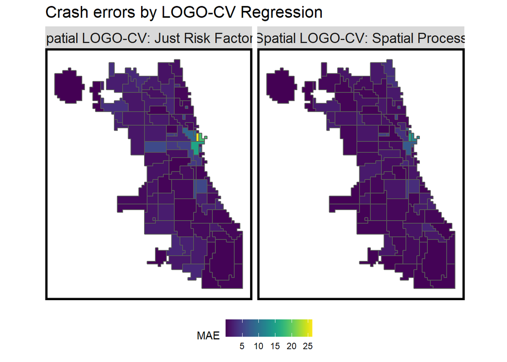

```r
error_by_reg_and_fold %>%
  filter(str_detect(Regression, "LOGO")) %>%
  ggplot() +
    geom_sf(aes(fill = MAE)) +
    facet_wrap(~Regression) +
    scale_fill_viridis() +
    labs(title = "Crash errors by LOGO-CV Regression") +
    mapTheme() + theme(legend.position="bottom")
```

Like in the histograms, the plots above show how adding spatial process makes the data less skewed, thus greater for overall accuracy or generalizability.

## Race context

```r
census_api_key("7fcf0c60997f4d8ccd298e26df0b2f35dc033150",install=TRUE, overwrite=TRUE)

acs_variable_list.2018 <- load_variables(2018,"acs5")

tracts18 <-
  get_acs(geography = "tract", variables = c("B01001_001E","B01001A_001E"),
          year = 2018, state=17, county=031, geometry=T) %>%
  st_transform('ESRI:102271')  %>%
  dplyr::select(variable, estimate, GEOID) %>%
  spread(variable, estimate) %>%
  rename(TotalPop = B01001_001,
         NumberWhites = B01001A_001) %>%
  mutate(percentWhite = NumberWhites / TotalPop,
         raceContext = ifelse(percentWhite > .5, "Majority_White", "Majority_Non_White")) %>%
  .[neighborhoods,]

reg.summary %>%
  filter(str_detect(Regression, "LOGO")) %>%
  st_centroid() %>%
  st_join(tracts18) %>%
  na.omit() %>%
  st_drop_geometry() %>%
  group_by(Regression, raceContext) %>%
  summarize(mean.Error = mean(Error, na.rm = T)) %>%
  spread(raceContext, mean.Error) %>%
  kable(caption = "Mean Error by neighborhood racial context") %>%
  kable_styling("striped", full_width = F)
```

[output not shown]